# Capstone Presentation: Yelp Data Set

02/20/2015

## Question

Is there a correlation between the frequency of how often someone reviews on Yelp and the amount they travel? If so, do more frequent reviewers travel more than non-frequent reviewers based off of the cities and coordinates they review at?

Why is this interesting?

- It could be helpful for organizational purposes on Yelp. If more frequent users travel more, maybe they could make recommendations of organizations for users to visit when they travel.

## Methods

- After cleaning, the end product was a dataframe that consisted only of the user ids, the number of cities visited, the maximum radius of travel, and the number of reviews made. Then models were made using the lm function in R:

```r
city.predict <- lm(cities~reviews, data = user_travel)
distance.predict <- lm(distance~reviews, data = user_travel)
```

- The residuals of these seem quadratic, so we add squared and cubed variables to the data and make a new model.

```r
city.predict2 <- lm(cities~reviews+reviewssq+reviewscu,
                    data = user_travel)
distance.predict2 <- lm(distance~reviews+reviewssq+reviewscu,
                        data = user_travel)
```

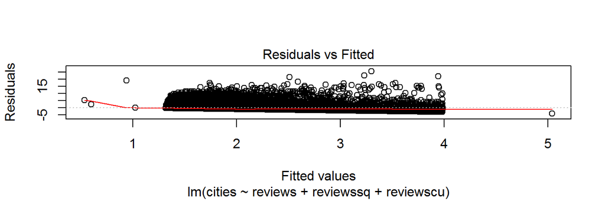

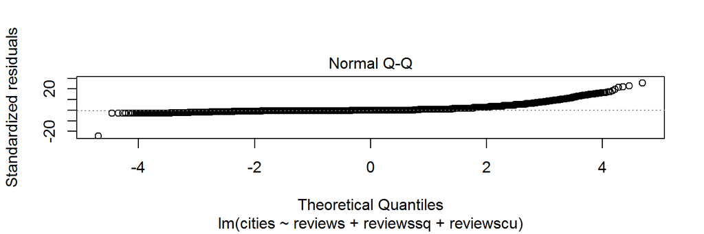

```r
plot(city.predict2, which=1:2, labels.id = '')
```

## Discussion

In retrospect, I wish I had more time to do the project. If I had more time, I would add other variables to the model to see if maybe they had more to do with the amount of travel a user makes rather than purely the reviews. I think this would make for interesting future work.